# Codon Usage Chemoreceptor Adaptiveness

10/1/2020

# Introduction

The purpose of this document is to compare codon usage for user-defined genes-of-interest against the codon usage of every CDS in the genomes of four *Strongyloides spp.* (and possibly *C. elegans*).

# Data Preprocessing

Full lists of CDS sequences for *S. stercoralis*, *S. ratti*, *S. papillosus*, *S. venezuelensis* and *C. elegans* were download from Wormbase ParaSite on October 1, 2020. The .fa files were used as input to the *Strongyloides* Codon Adapter App. For each species an excel report containing the computed codon adaptation index values relative to *S. ratti* and *C. elegans* was downloaded; these file are uploaded the code chunks below.

For user-defined genes-of-interest, a list of *S. stercoralis* chemoreceptor genes was used as input to the *Strongyloides* Codon Adapter App; the generated excel report is uploaded below.

## Parse Species-specific lists of chemoreceptors

Cleaning and data wrangling for chemoreceptor gene lists; necessary prepreocessing step before running lists of genes through the *Strongyloides* Codon Adapter App. Gene lists were downloaded from a Shiny app provided for this purpose by [Wheeler *et al* 2020](https://journals.plos.org/plosbiology/article?id=10.1371/journal.pbio.3000723). Species for which we have lists of chemoreceptors are: *C. elegans*, *S. stercoralis*, *S. ratti*, and *S. venezuelensis*. Data are saved as 2-column .csv files containing geneIDs and cDNA sequences; these files can be used as inputs to the *Strongyloides* Codon Adapter App.

```r
# C. elegans ----
temp <- c(Ce = '../Data/Ce_chemoreceptors.csv')
genelist.Ce <- suppressWarnings(read.csv(temp,
                                         header = TRUE,
                                         colClasses = "character",
                                         strip.white = T)) %>%
  as_tibble()

## For C. elegans, match wormbase gene sequence name to the wbsp transcript id, and pull the cDNA sequence
Ce.tr.seq <- getBM(attributes=c('wbps_transcript_id', 'cdna'),
                   # grab the cDNA sequences for the given genes from WormBase Parasite
                   mart = useMart(biomart="parasite_mart",
                                  dataset = "wbps_gene",
                                  host="https://parasite.wormbase.org",
                                  port = 443),
                   filters = c('species_id_1010',
                               'wormbase_gseqname'),
                   values = list('caelegprjna13758',
                                 genelist.Ce$Transcript_ID),
                   useCache = F) %>%
  as_tibble() %>%
  #we need to rename the columns retreived from biomart
  dplyr::rename(geneID = wbps_transcript_id, cDNA = cdna)
Ce.tr.seq$cDNA <- tolower(Ce.tr.seq$cDNA)

write.table(Ce.tr.seq, file = "./Ce_chemosensory_cDNA_list.csv", sep = ",", col.names = FALSE, row.names = FALSE)

# S. ratti ----
temp <- c(Sr = '../Data/Sr_chemoreceptors.csv')

genelist.Sr <- suppressWarnings(read.csv(temp,
                                         header = TRUE,
                                         colClasses = "character",
                                         strip.white = T)) %>%
  as_tibble()

## For ratti, match wormbase gene sequence name to the wbsp transcript id, and pull the cDNA sequence
Sr.tr.seq <- getBM(attributes=c('wbps_transcript_id', 'cdna'),
                   # grab the cDNA sequences for the given genes from WormBase Parasite
                   mart = useMart(biomart="parasite_mart",
                                  dataset = "wbps_gene",
                                  host="https://parasite.wormbase.org",
                                  port = 443),
                   filters = c('species_id_1010',
                               'wbps_transcript_id'),
                   values = list('strattprjeb125',
                                 genelist.Sr$Transcript_ID),
                   useCache = T) %>%
  as_tibble() %>%
  #we need to rename the columns retreived from biomart
  dplyr::rename(geneID = wbps_transcript_id, cDNA = cdna)
Sr.tr.seq$cDNA <- tolower(Sr.tr.seq$cDNA)

write.table(Sr.tr.seq, file = "./Sr_chemosensory_cDNA_list.csv", sep = ",", col.names = FALSE, row.names = FALSE)

# S. venezuelensis ----
temp <- c(Sv = '../Data/Sv_chemoreceptors.csv')

genelist.Sv <- suppressWarnings(read.csv(temp,
                                         header = TRUE,
                                         colClasses = "character",
                                         strip.white = T)) %>%
  as_tibble()

## For ratti, match wormbase gene sequence name to the wbsp transcript id, and pull the cDNA sequence
Sv.tr.seq <- getBM(attributes=c('wbps_transcript_id', 'cdna'),
                   # grab the cDNA sequences for the given genes from WormBase Parasite
                   mart = useMart(biomart="parasite_mart",
                                  dataset = "wbps_gene",
                                  host="https://parasite.wormbase.org",
                                  port = 443),
                   filters = c('species_id_1010',
                               'wbps_transcript_id'),
                   values = list('stveneprjeb530',
                                 genelist.Sv$Transcript_ID),
                   useCache = T) %>%
  as_tibble() %>%
  #we need to rename the columns retreived from biomart
  dplyr::rename(geneID = wbps_transcript_id, cDNA = cdna)
Sv.tr.seq$cDNA <- tolower(Sv.tr.seq$cDNA)

write.table(Sv.tr.seq, file = "./Sv_chemosensory_cDNA_list.csv", sep = ",", col.names = FALSE, row.names = FALSE)
```

# Analysis/Results

## Load Genome Data

For each species, load data listing GC content and CAI indeces for the full list of CDS elements in genome.

```r
temp <- c(Ss = './Ss_Codon_Usage_Report.xlsx',
          Sr = './Sr_Codon_Usage_Report.xlsx',
          Sp = './Sp_Codon_Usage_Report.xlsx',
          Sv = './Sv_Codon_Usage_Report.xlsx',
          Ce = './Ce_Codon_Usage_Report.xlsx')
dat.genomic <- sapply(temp, read_excel,
                      sheet = 1,
                      skip = 3,
                      col_names = T,
                      simplify = F,
                      USE.NAMES = T)

dat.genomic.df <- dat.genomic %>%
    map("geneID") %>%
    unlist() %>%
    as_tibble_col(column_name = "geneID") %>%
    group_by

dat.genomic.df <- dat.genomic %>%
    map("Sr_CAI") %>%
    unlist() %>%
    as_tibble_col(column_name = "Sr_CAI") %>%
    add_column(dat.genomic.df, .)

dat.genomic.df <- dat.genomic %>%
    map("Ce_CAI") %>%
    unlist() %>%
    as_tibble_col(column_name = "Ce_CAI") %>%
    add_column(dat.genomic.df, .)

# Add the column that species which species the gene is from
# by matching to the original lists of genes,
# the group
dat.genomic.df <- dat.genomic.df %>%
    dplyr::mutate(species = case_when(
        geneID %in% dat.genomic$Ss$geneID ~ 'Ss',
        geneID %in% dat.genomic$Sr$geneID ~ 'Sr',
        geneID %in% dat.genomic$Sp$geneID ~ 'Sp',
        geneID %in% dat.genomic$Sv$geneID ~ 'Sv',
        geneID %in% dat.genomic$Ce$geneID ~ 'Ce',
    ))
dat.genomic.df <- group_by(dat.genomic.df, species)
```

## Plotting Distribution of CAI Values

This section takes the calculated codon adaptation index values for all predicted codoning sequences, and generates a density plot for each species. Ideally, this plot could be used to benchmark the calculated CAI values against other metrics of codon bias in these species. For example, Mitreva *et al* 2006 reported effective number of codons (ENC) as a measure of gene-wise codon bias, across species. They report that “mean ENC across all sampled nemtaode species is 46.7 +/- 5.1” but that *S. stercoralis* and *S. ratti* are outliers with low ENC values (~35). Note: ENC values range from 20 for highly biased to 61 for no bias. Thus, benchmarking from Mitreva *et al* 2006, we might expect that *Strongyloides* species will have greater codon bias than *C. elegans*. Unfortunately, although they do report measuring distribution of ENC values across all transcripts for each species, they only have plots for *S. ratti*, *P. trichosuri* and *P. pacificus*.

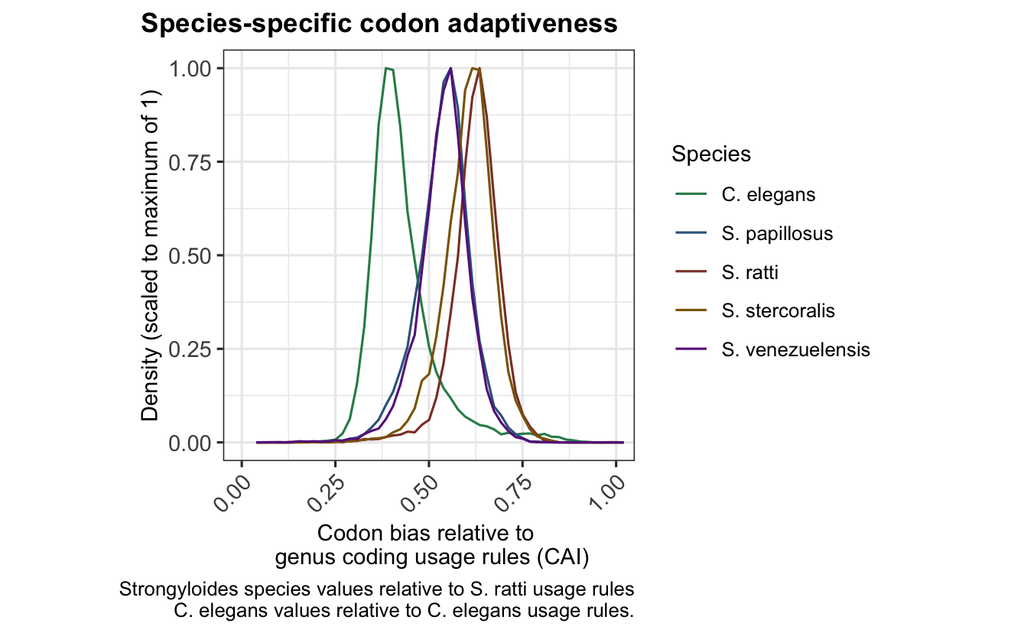

Notes re: the above plot - *C. elegans* shows overall lower codon bias compared to the *Strongyloides* species, as predicted from the Mitreva *et al* 2006 results. Reminder that Mitreva *et al* reported that this difference is greatly affected by the GC content; more AT rich speices like the *Strongyloides* species have greater codon usage biases. Also, it looks like the *Strongyloides* subclades (*S. ratti* - *S. stercoralis*; *S. papillosus* - *S. venezuelensis*) cluster together.